# Partial Mortality

Shayle Matsuda

5/20/2020

Matsuda, SB, Huffmyer, AS, Lenz, E, Davidson, J, Hancock, J, Pryzybylowski, A, Innis, T, Gates, RD, and KL Barott. Coral bleaching susceptibility is predictive of subsequent mortality within but not between coral species.

Tissue partial mortality analysis for *M. capitata* and *P. compressa* colonies at the Inner Lagoon (PR4) and Outer Lagoon (PR13) after the 2015 coral bleaching event in Kaneohe Bay. Mortality scores are in % to the nearest 20%

```r
rm(list=ls(all=TRUE))
library("reshape2") #reshape data
library("ggplot2") #plotting
library("reshape") #reshape data
library("plyr")  #splitting, applying, and combining data
library("dplyr")  #splitting, applying, and combining data
library("plotrix") #plotting
library("gridExtra") #arrange plots for output
library("lsmeans")
library("multcomp")
library("multcompView")
library("lme4")
library("lmerTest")
#load data
mData<-read.csv("data/Mortality_scores_percent.csv")
mData$Site<-as.factor(mData$Site)

#We excluded these pairs as part of the pair analysis because the Bleached coral was only a 2: Porites Outer Bay 233_234, Porites Inner Bay 297_298, Porites Outer Bay 227_228, Montipora capitata Inner Bay 251_252.
```

# Partial mortality

```r
#all Months
  mALL<-mData
  #melt
  mALLData1<-melt(data = mALL, measure.vars = c("Month0","Month1.5","Month3","Month4.5", "Month6","Month10","Month18","Month24"))
  colnames(mALLData1)[colnames(mALLData1)=="variable"] <- "month"   # change col name from 'variable' to 'month'
  colnames(mALLData1)[colnames(mALLData1)=="value"] <- "score"   # change col name from 'value' to 'score'

#Remove all NON PAIRS and all NAs
  mALLData<-na.omit(mALLData1) # remove the NA colums

#Change scores into %
mALLDataPER<-mALLData
mALLDataPER$Score<-mALLDataPER$score*100

#recast for rate cals
mALLData_cast<-dcast(mALLData, TagID+Pair+Species+Site+B2015~month)
```

```r
#Mean partial mortality scores:
#calc average tissue loss score per grouping by time point
mALLmeans <- ddply(mALLData, c("Site", "Species", "B2015", "month"), summarise, #
                   N    = length(score[!is.na(score)]), #calculate the length of the data frame, excluding NA’s *this part is important*
                   mean = mean(score, na.rm=TRUE), #calculate mean of response variable, removing NA's
                   sd   = sd(score, na.rm=TRUE), #calculate standard deviation
                   se   = sd / sqrt(N), #calculate standard error
                   max = max(score, na.rm=TRUE) #calculate max, could also calculate min () if desired
)
mALLmeans$code<-paste0(mALLmeans$Site, mALLmeans$B2015, mALLmeans$Species)
```

```r
#Partial mortality score means 0-24 months by species/site/bleaching history
#calc average tissue loss score per grouping by time point
mALLmeansPER <- ddply(mALLDataPER, c("Site", "Species", "B2015", "month"), summarise, #
                   N    = length(Score[!is.na(Score)]), #calculate the length of the data frame, excluding NA’s *this part is important*
                   mean = mean(Score, na.rm=TRUE), #calculate mean of response variable, removing NA's
                   sd   = sd(Score, na.rm=TRUE), #calculate standard deviation
                   se   = sd / sqrt(N), #calculate standard error
                   max = max(Score, na.rm=TRUE) #calculate max, could also calculate min () if desired
)
mALLmeansPER$code<-paste0(mALLmeansPER$Site, mALLmeansPER$B2015, mALLmeansPER$Species)
```

# Figure 5

Average color score (A-D) and partial mortality (E-H) of bleaching susceptible versus bleaching resistant colonies of Montipora capitata (A, B, E, F) and Porites compressa (C, D, G, H) at the Inner Lagoon (A,C, E, G) and Outer Lagoon (B, D, F, H) from the peak of the coral bleaching event (Sept. – Oct. 2015) through the following 24 months of recovery. Solid lines indicate bleaching resistant colonies; dashed lines indicate bleaching susceptible colonies. Color scores: 1, white; 2, pale; 3, pigmented. Error bars indicate SEM.

```r
#subset for Mcap only
Mcap024AllplotM<-subset(mALLmeansPER, Species=="Montipora capitata")     #subset Mcap
Mcap024AllplotM$Month[Mcap024AllplotM$month=="Month0"]<-0     # new col with month #s only
Mcap024AllplotM$Month[Mcap024AllplotM$month=="Month1.5"]<-1.5
Mcap024AllplotM$Month[Mcap024AllplotM$month=="Month3"]<-3
Mcap024AllplotM$Month[Mcap024AllplotM$month=="Month4.5"]<-4.5
Mcap024AllplotM$Month[Mcap024AllplotM$month=="Month6"]<-6
Mcap024AllplotM$Month[Mcap024AllplotM$month=="Month10"]<-10
Mcap024AllplotM$Month[Mcap024AllplotM$month=="Month18"]<-18
Mcap024AllplotM$Month[Mcap024AllplotM$month=="Month24"]<-24

#PR13
Mcap024AllplotPR13M<-subset(Mcap024AllplotM, Site=="13")
#PR4
Mcap024AllplotPR4M<-subset(Mcap024AllplotM, Site==4)
```

```r
#*Montipora capitata*  Figure
mallplotMcapPR13<-ggplot(data=Mcap024AllplotPR13M, aes(x=Month, y=mean, group = code, color=B2015)) + #color by bleaching hist.
  geom_errorbar(aes(ymin=mean-se, ymax=mean+se),
                width=0.1,show.legend = FALSE)+
  geom_point(aes(shape=B2015),fill="mediumblue", size=5)+
  scale_shape_manual(values=c( 16,1))+
  geom_line(aes(color=B2015, linetype=B2015))+
  scale_linetype_manual(values=c("solid", "dotted"))+
  scale_color_manual(values=c("black","black"))+
    scale_x_continuous(breaks = seq(0, 24, by = 6))+
  ylab("Percent")+
    ylim(0, 80) + #set Y limits
  theme_bw() + #Set the background color
  theme(axis.line = element_line(color = 'black'), #Set the axes color
        axis.title=element_text(size=14,face="bold"), #Set axis format
        panel.border = element_blank(), #Set the border
        panel.grid.major = element_blank(), #Set the major gridlines
        panel.grid.minor = element_blank(), #Set the minor gridlines
        plot.background =element_blank(), #Set the plot background
        legend.key = element_blank()) + #Set plot legend key
          theme(plot.title = element_text(size=20,face = "bold",hjust = 0.5))
McapOuter<-mallplotMcapPR13 + theme(legend.position = "none") #remove legend

#Mcap Inner
ballplotMcapPR4M<-ggplot(data=Mcap024AllplotPR4M, aes(x=Month, y=mean, group = code, color=B2015),show.legend = FALSE) + #color by bleaching hist.
 geom_errorbar(aes(ymin=mean-se, ymax=mean+se),
                width=0.1,show.legend = FALSE)+
  geom_point(aes(shape=B2015),fill="mediumblue", size=5)+
  scale_shape_manual(values=c( 16,1))+
  geom_line(aes(color=B2015, linetype=B2015))+
  scale_linetype_manual(values=c("solid", "dotted"))+
  scale_color_manual(values=c("black","black"))+
    scale_x_continuous(breaks = seq(0, 24, by = 6))+
    ylim(0, 80) + #set Y limits
  theme_bw() + #Set the background color
  ylab("Percent")+
  theme(axis.line = element_line(color = 'black'), #Set the axes color
        axis.title=element_text(size=14,face="bold"), #Set axis format
        panel.border = element_blank(), #Set the border
        panel.grid.major = element_blank(), #Set the major gridlines
        panel.grid.minor = element_blank(), #Set the minor gridlines
        plot.background =element_blank(), #Set the plot background
        legend.key = element_blank()) + #Set plot legend key
 # ggtitle("Inner Lagoon")+
          theme(plot.title = element_text(size=20,face = "bold", hjust = 0.5))
McapInnerMORT<-ballplotMcapPR4M + theme(legend.position = "none") #remove legend
```

```r
#*Porites compressa* Figures

Pcomp024Allplot<-subset(mALLmeansPER, Species=="Porites compressa")

# change Month# to just number
Pcomp024Allplot$Month[Pcomp024Allplot$month=="Month0"]<-0
Pcomp024Allplot$Month[Pcomp024Allplot$month=="Month1.5"]<-1.5
Pcomp024Allplot$Month[Pcomp024Allplot$month=="Month3"]<-3
Pcomp024Allplot$Month[Pcomp024Allplot$month=="Month4.5"]<-4.5
Pcomp024Allplot$Month[Pcomp024Allplot$month=="Month6"]<-6
Pcomp024Allplot$Month[Pcomp024Allplot$month=="Month10"]<-10
Pcomp024Allplot$Month[Pcomp024Allplot$month=="Month18"]<-18
Pcomp024Allplot$Month[Pcomp024Allplot$month=="Month24"]<-24

Pcomp024AllplotPR13<-subset(Pcomp024Allplot, Site==13)
Pcomp024AllplotPR4<-subset(Pcomp024Allplot, Site==4)

#Pcomp PR13 plot
b024plotPcompPR13<-ggplot(data=Pcomp024AllplotPR13, aes(x=Month, y=mean, group = code, color=B2015)) + #color by bleaching hist.
  geom_errorbar(aes(ymin=mean-se, ymax=mean+se),
                width=0.1,show.legend = FALSE)+
  geom_point(aes(shape=B2015),fill="mediumblue", size=5)+
  scale_shape_manual(values=c( 16,1))+
  geom_line(aes(color=B2015, linetype=B2015))+
  scale_linetype_manual(values=c("solid", "dotted"))+
  scale_color_manual(values=c("black","black"))+
    scale_x_continuous(breaks = seq(0, 24, by = 6))+
    ylim(0,80) + #set Y limits
    ylab("Percent")+
  theme_bw() + #Set the background color
  theme(axis.line = element_line(color = 'black'), #Set the axes color
        axis.title=element_text(size=14,face="bold"), #Set axis format
        panel.border = element_blank(), #Set the border
        panel.grid.major = element_blank(), #Set the major gridlines
        panel.grid.minor = element_blank(), #Set the minor gridlines
        plot.background =element_blank(), #Set the plot background
        legend.key = element_blank()) + #Set plot legend key
          theme(plot.title = element_text(size=20,face = "italic"))
PcompOuter<-b024plotPcompPR13+ theme(legend.position = "none") #remove legend

#Pcomp PR4 plot
b024plotPcompPR4<-ggplot(data=Pcomp024AllplotPR4, aes(x=Month, y=mean, group = code, color=B2015)) + #color by bleaching hist.
  geom_errorbar(aes(ymin=mean-se, ymax=mean+se),
                width=0.1,show.legend = FALSE)+
  geom_point(aes(shape=B2015),fill="mediumblue", size=5)+
  scale_shape_manual(values=c( 16,1))+
  geom_line(aes(color=B2015, linetype=B2015))+
  scale_linetype_manual(values=c("solid", "dotted"))+
  scale_color_manual(values=c("black","black"))+
    scale_x_continuous(breaks = seq(0, 24, by = 6))+
    ylim(0,80) + #set Y limits
    ylab("Percent")+
  theme_bw() + #Set the background color
  theme(axis.line = element_line(color = 'black'), #Set the axes color
        axis.title=element_text(size=14,face="bold"), #Set axis format
        panel.border = element_blank(), #Set the border
        panel.grid.major = element_blank(), #Set the major gridlines
        panel.grid.minor = element_blank(), #Set the minor gridlines
        plot.background =element_blank(), #Set the plot background
        legend.key = element_blank()) + #Set plot legend key
          theme(plot.title = element_text(size=20,face = "italic"))
PcompInner<-b024plotPcompPR4+ theme(legend.position = "none") #remove legend
```

Figure 5 (E, F, G, H) *(Partial mortality figure, full figure includes color score data (see ColorScore.Rmd))*

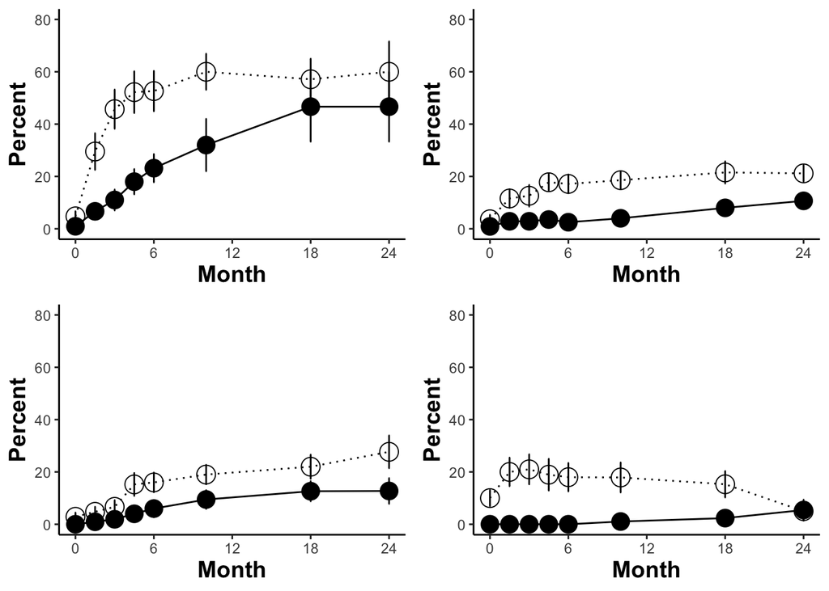

```r
grid.arrange(McapInnerMORT, McapOuter, PcompInner,PcompOuter, nrow = 2)
```

# Table 3:

```r
#subset by species
Mcap_mort<-subset(mALLDataPER, Species=="Montipora capitata")
Pcomp_mort<-subset(mALLDataPER, Species=="Porites compressa")
```

*M. capitata*

```r
#Mcap
Mcap_mort_mod<-lmer(Score~Site*B2015*month+(1|TagID), Mcap_mort)
anova(Mcap_mort_mod, type=2)
```

```
## Type II Analysis of Variance Table with Satterthwaite's method
##                  Sum Sq Mean Sq NumDF  DenDF F value    Pr(>F)
## Site               5129  5129.0     1  84.74 39.6140 1.310e-08 ***
## B2015              2868  2868.5     1  84.64 22.1549 9.721e-06 ***
## month             39812  5687.5     7 433.07 43.9276 < 2.2e-16 ***
## Site:B2015          515   515.4     1  84.90  3.9807   0.04923 *
## Site:month        18490  2641.4     7 433.34 20.4010 < 2.2e-16 ***
## B2015:month        5986   855.1     7 433.20  6.6046 1.974e-07 ***
## Site:B2015:month   2176   310.8     7 433.42  2.4008   0.02030 *
## ---
## Signif. codes:  0 '***' 0.001 '**' 0.01 '*' 0.05 '.' 0.1 ' ' 1
```

Tukey post hoc test:

```r
emm = emmeans(Mcap_mort_mod, ~ Site*month, adjust="tukey")

pairs(emm)
```

*P. compressa*

```r
Pcomp_mort_mod<-lmer(Score~Site*B2015*month+(1|TagID), Pcomp_mort)
anova(Pcomp_mort_mod, type=2)
```

```
## Type II Analysis of Variance Table with Satterthwaite's method
##                  Sum Sq Mean Sq NumDF  DenDF F value    Pr(>F)
## Site                2.5    2.48     1  77.94  0.0368 0.8483854
## B2015            1132.3 1132.34     1  77.94 16.7988 0.0001011 ***
## month            7181.9 1025.98     7 493.77 15.2209 < 2.2e-16 ***
## Site:B2015        139.8  139.76     1  77.94  2.0734 0.1538874
## Site:month       5423.3  774.75     7 493.78 11.4938 1.497e-13 ***
## B2015:month      1084.6  154.95     7 493.78  2.2987 0.0259105 *
## Site:B2015:month 1112.8  158.97     7 493.78  2.3583 0.0223464 *
## ---
## Signif. codes:  0 '***' 0.001 '**' 0.01 '*' 0.05 '.' 0.1 ' ' 1
```

Tukey post hoc test:

```r
emm = emmeans(Pcomp_mort_mod, ~ Site*month, adjust="tukey")

pairs(emm)
```

# Supplementary Tables 7

Analysis of Variance Table of the effects of lagoon and bleaching phenotype on partial mortality of Montipora capitata and Porites compressa by recovery month from peak bleaching to 24 months of recovery (`Partial Mortality ~ Lagoon*Phenotype+(1|Coral Tag ID)`). Bold indicates statistical significance.  
*Montipora capiatata* Month0

```r
Mcap_m0<-subset(Mcap_mort, month=="Month0")
Mcap_m0_mod1<-lm(score~Site*B2015, Mcap_m0)
#summary(Mcap_m0_mod1)
anova(Mcap_m0_mod1)
```

```
## Analysis of Variance Table
##
## Response: score
##            Df  Sum Sq   Mean Sq F value  Pr(>F)
## Site        1 0.00073 0.0007339  0.1674 0.68353
## B2015       1 0.02279 0.0227907  5.1975 0.02522 *
## Site:B2015  1 0.00063 0.0006292  0.1435 0.70581
## Residuals  82 0.35957 0.0043850
## ---
## Signif. codes:  0 '***' 0.001 '**' 0.01 '*' 0.05 '.' 0.1 ' ' 1
```

Month1.5

```r
Mcap_m1_5<-subset(Mcap_mort, month=="Month1.5")
Mcap_m1_5_mod1<-lm(score~Site*B2015, Mcap_m1_5)
#summary(Mcap_m1_5_mod1)
anova(Mcap_m1_5_mod1)
```

```
## Analysis of Variance Table
##
## Response: score
##            Df  Sum Sq Mean Sq F value    Pr(>F)
## Site        1 0.25221 0.25221  6.9165 0.0102853 *
## B2015       1 0.52224 0.52224 14.3215 0.0003008 ***
## Site:B2015  1 0.10221 0.10221  2.8029 0.0980993 .
## Residuals  78 2.84431 0.03647
## ---
## Signif. codes:  0 '***' 0.001 '**' 0.01 '*' 0.05 '.' 0.1 ' ' 1
```

Tukey post hoc test:

```r
emm = emmeans(Mcap_m1_5_mod1, ~ B2015, adjust="tukey")

    cld(emm)
```

Month3

```r
Mcap_m3<-subset(Mcap_mort, month=="Month3")
Mcap_m3_mod1<-lm(score~Site*B2015, Mcap_m3)
#summary(Mcap_m3_mod1)
anova(Mcap_m3_mod1)
```

```
## Analysis of Variance Table
##
## Response: score
##            Df Sum Sq Mean Sq F value    Pr(>F)
## Site        1 0.9169 0.91690 19.5619 3.158e-05 ***
## B2015       1 1.0154 1.01543 21.6640 1.329e-05 ***
## Site:B2015  1 0.3143 0.31435  6.7065   0.01148 *
## Residuals  77 3.6091 0.04687
## ---
## Signif. codes:  0 '***' 0.001 '**' 0.01 '*' 0.05 '.' 0.1 ' ' 1
```

Tukey post hoc test:

```r
   emm = emmeans(Mcap_m3_mod1, ~ B2015, adjust="tukey") #B2015

      cld(emm)
      emm = emmeans(Mcap_m3_mod1, ~ Site, adjust="tukey") #B2015

      cld(emm)
      #conduct Tukey post hoc test:
      emm = emmeans(Mcap_m3_mod1, ~ Site*B2015, adjust="tukey")  #B2015*Site

      pairs(emm)
```

Month4.5

```r
Mcap_m4_5<-subset(Mcap_mort, month=="Month4.5")
Mcap_m4_5_mod1<-lm(score~Site*B2015, Mcap_m4_5)
#summary(Mcap_m4_5_mod1)
anova(Mcap_m4_5_mod1)
```

```
## Analysis of Variance Table
##
## Response: score
##            Df Sum Sq Mean Sq F value    Pr(>F)
## Site        1 0.9936 0.99364 21.3383 1.734e-05 ***
## B2015       1 1.1056 1.10562 23.7431 6.755e-06 ***
## Site:B2015  1 0.1814 0.18140  3.8955   0.05242 .
## Residuals  69 3.2130 0.04657
## ---
## Signif. codes:  0 '***' 0.001 '**' 0.01 '*' 0.05 '.' 0.1 ' ' 1
```

Tukey post hoc test: :

```r
 emm = emmeans(Mcap_m4_5_mod1, ~ B2015, adjust="tukey") #B2015

      cld(emm)
      #conduct Tukey post hoc test:
      emm = emmeans(Mcap_m4_5_mod1, ~ Site, adjust="tukey")  #Site

      cld(emm)
```

Month6

```r
Mcap_m6<-subset(Mcap_mort, month=="Month6")
Mcap_m6_mod1<-lm(score~Site*B2015, Mcap_m6)
#summary(Mcap_m6_mod1)
anova(Mcap_m6_mod1)
```

```
## Analysis of Variance Table
##
## Response: score
##            Df Sum Sq Mean Sq F value    Pr(>F)
## Site        1 1.3676 1.36759 26.5513 2.667e-06 ***
## B2015       1 0.8934 0.89340 17.3451 9.511e-05 ***
## Site:B2015  1 0.0920 0.09196  1.7853    0.1862
## Residuals  64 3.2965 0.05151
## ---
## Signif. codes:  0 '***' 0.001 '**' 0.01 '*' 0.05 '.' 0.1 ' ' 1
```

Tukey post hoc test:

```r
 emm = emmeans(Mcap_m6_mod1, ~ B2015, adjust="tukey") #B2015

      cld(emm)
      #conduct Tukey post hoc test:
      emm = emmeans(Mcap_m6_mod1, ~ Site, adjust="tukey")  #Site

      cld(emm)
```

Month10

```r
Mcap_m10<-subset(Mcap_mort, month=="Month10")
Mcap_m10_mod1<-lm(score~Site*B2015, Mcap_m10)
#summary(Mcap_m10_mod1)
anova(Mcap_m10_mod1)
```

```
## Analysis of Variance Table
##
## Response: score
##            Df  Sum Sq Mean Sq F value    Pr(>F)
## Site        1 2.08276 2.08276  43.863 1.976e-08 ***
## B2015       1 0.58665 0.58665  12.355 0.0009207 ***
## Site:B2015  1 0.06073 0.06073   1.279 0.2632695
## Residuals  52 2.46914 0.04748
## ---
## Signif. codes:  0 '***' 0.001 '**' 0.01 '*' 0.05 '.' 0.1 ' ' 1
```

Tukey post hoc test:

```r
emm = emmeans(Mcap_m10_mod1, ~ B2015, adjust="tukey") #B2015

      cld(emm)
      #conduct Tukey post hoc test:
      emm = emmeans(Mcap_m10_mod1, ~ Site, adjust="tukey")  #Site

      cld(emm)
```

Month18

```r
Mcap_m18<-subset(Mcap_mort, month=="Month18")
Mcap_m18_mod1<-lm(score~Site*B2015, Mcap_m18)
#summary(Mcap_m18_mod1)
anova(Mcap_m18_mod1)
```

```
## Analysis of Variance Table
##
## Response: score
##            Df  Sum Sq Mean Sq F value    Pr(>F)
## Site        1 1.84010 1.84010 39.2491 1.376e-07 ***
## B2015       1 0.17129 0.17129  3.6535   0.06248 .
## Site:B2015  1 0.00246 0.00246  0.0524   0.81999
## Residuals  44 2.06283 0.04688
## ---
## Signif. codes:  0 '***' 0.001 '**' 0.01 '*' 0.05 '.' 0.1 ' ' 1
```

Tukey post hoc test:

```r
emm = emmeans(Mcap_m18_mod1, ~ Site, adjust="tukey")  #Site

      cld(emm)
```

Month24

```r
Mcap_m24<-subset(Mcap_mort, month=="Month24")
Mcap_m24_mod1<-lm(score~Site*B2015, Mcap_m24)
#summary(Mcap_m24_mod1)
anova(Mcap_m24_mod1)
```

```
## Analysis of Variance Table
##
## Response: score
##            Df  Sum Sq Mean Sq F value    Pr(>F)
## Site        1 1.50724 1.50724 33.7504 6.916e-07 ***
## B2015       1 0.15004 0.15004  3.3598   0.07374 .
## Site:B2015  1 0.00198 0.00198  0.0443   0.83435
## Residuals  43 1.92031 0.04466
## ---
## Signif. codes:  0 '***' 0.001 '**' 0.01 '*' 0.05 '.' 0.1 ' ' 1
```

Tukey post hoc test:

```r
 emm = emmeans(Mcap_m24_mod1, ~ Site, adjust="tukey")  #Site

      cld(emm)
```

*Porites compressa*  
Month0

```r
Pcomp_m0<-subset(Pcomp_mort, month=="Month0")
Pcomp_m0_mod1<-lm(score~Site*B2015, Pcomp_m0)
#summary(Pcomp_m0_mod1)
anova(Pcomp_m0_mod1)
```

```
## Analysis of Variance Table
##
## Response: score
##            Df  Sum Sq  Mean Sq F value    Pr(>F)
## Site        1 0.02613 0.026132  4.4038 0.0390953 *
## B2015       1 0.08244 0.082439 13.8925 0.0003648 ***
## Site:B2015  1 0.02613 0.026132  4.4038 0.0390953 *
## Residuals  78 0.46286 0.005934
## ---
## Signif. codes:  0 '***' 0.001 '**' 0.01 '*' 0.05 '.' 0.1 ' ' 1
```

Tukey post hoc test:

```r
 emm = emmeans(Pcomp_m0_mod1, ~ Site*B2015, adjust="tukey")

  cld(emm)
```

Month1.5

```r
Pcomp_m1_5<-subset(Pcomp_mort, month=="Month1.5")
Pcomp_m1_5_mod1<-lm(score~Site*B2015, Pcomp_m1_5)
#summary(Pcomp_m1_5_mod1)
anova(Pcomp_m1_5_mod1)
```

```
## Analysis of Variance Table
##
## Response: score
##            Df  Sum Sq  Mean Sq F value    Pr(>F)
## Site        1 0.10453 0.104530  6.2216 0.0147344 *
## B2015       1 0.28098 0.280976 16.7238 0.0001043 ***
## Site:B2015  1 0.13426 0.134262  7.9913 0.0059687 **
## Residuals  78 1.31048 0.016801
## ---
## Signif. codes:  0 '***' 0.001 '**' 0.01 '*' 0.05 '.' 0.1 ' ' 1
```

Tukey post hoc test:

```r
emm = emmeans(Pcomp_m1_5_mod1, ~ Site*B2015, adjust="tukey")

  cld(emm)
```

Month3

```r
Pcomp_m3<-subset(Pcomp_mort, month=="Month3")
Pcomp_m3_mod1<-lm(score~Site*B2015, Pcomp_m3)
#summary(Pcomp_m3_mod1)
anova(Pcomp_m3_mod1)
```

```
## Analysis of Variance Table
##
## Response: score
##            Df  Sum Sq Mean Sq F value    Pr(>F)
## Site        1 0.07912 0.07912  3.7242 0.0572640 .
## B2015       1 0.32976 0.32976 15.5222 0.0001764 ***
## Site:B2015  1 0.13505 0.13505  6.3572 0.0137295 *
## Residuals  78 1.65705 0.02124
## ---
## Signif. codes:  0 '***' 0.001 '**' 0.01 '*' 0.05 '.' 0.1 ' ' 1
```

Tukey post hoc test:

```r
emm = emmeans(Pcomp_m3_mod1, ~ Site*B2015, adjust="tukey")

  cld(emm)
```

Month4.5

```r
Pcomp_m4_5<-subset(Pcomp_mort, month=="Month4.5")
Pcomp_m4_5_mod1<-lm(score~Site*B2015, Pcomp_m4_5)
#summary(Pcomp_m4_5_mod1)
anova(Pcomp_m4_5_mod1)
```

```
## Analysis of Variance Table
##
## Response: score
##            Df  Sum Sq Mean Sq F value    Pr(>F)
## Site        1 0.00055 0.00055  0.0187 0.8915075
## B2015       1 0.44949 0.44949 15.2624 0.0002013 ***
## Site:B2015  1 0.02968 0.02968  1.0078 0.3186279
## Residuals  76 2.23828 0.02945
## ---
## Signif. codes:  0 '***' 0.001 '**' 0.01 '*' 0.05 '.' 0.1 ' ' 1
```

Tukey post hoc test:

```r
emm = emmeans(Pcomp_m4_5_mod1, ~ B2015, adjust="tukey")

  cld(emm)
```

Month6

```r
Pcomp_m6<-subset(Pcomp_mort, month=="Month6")
Pcomp_m6_mod1<-lm(score~Site*B2015, Pcomp_m6)
#summary(Pcomp_m6_mod1)
anova(Pcomp_m6_mod1)
```

```
## Analysis of Variance Table
##
## Response: score
##            Df Sum Sq Mean Sq F value    Pr(>F)
## Site        1  0.008 0.00800  0.2969 0.5874435
## B2015       1  0.392 0.39200 14.5469 0.0002764 ***
## Site:B2015  1  0.032 0.03200  1.1875 0.2792776
## Residuals  76  2.048 0.02695
## ---
## Signif. codes:  0 '***' 0.001 '**' 0.01 '*' 0.05 '.' 0.1 ' ' 1
```

Tukey post hoc test:

```r
 emm = emmeans(Pcomp_m6_mod1, ~ B2015, adjust="tukey")

  cld(emm)
```

Month10

```r
Pcomp_m10<-subset(Pcomp_mort, month=="Month10")
Pcomp_m10_mod1<-lm(score~Site*B2015, Pcomp_m10)
#summary(Pcomp_m10_mod1)
anova(Pcomp_m10_mod1)
```

```
## Analysis of Variance Table
##
## Response: score
##            Df  Sum Sq Mean Sq F value   Pr(>F)
## Site        1 0.04593 0.04593  1.5991 0.210054
## B2015       1 0.33215 0.33215 11.5631 0.001094 **
## Site:B2015  1 0.02574 0.02574  0.8962 0.346921
## Residuals  73 2.09695 0.02873
## ---
## Signif. codes:  0 '***' 0.001 '**' 0.01 '*' 0.05 '.' 0.1 ' ' 1
```

Tukey post hoc test:

```r
 emm = emmeans(Pcomp_m10_mod1, ~ B2015, adjust="tukey")

  cld(emm)
  #conduct Tukey post hoc test:
  emm = emmeans(Pcomp_m10_mod1, ~ B2015, adjust="tukey")

  cld(emm)
```

Month18

```r
Pcomp_m18<-subset(Pcomp_mort, month=="Month18")
Pcomp_m18_mod1<-lm(score~Site*B2015, Pcomp_m18)
#summary(Pcomp_m18_mod1)
anova(Pcomp_m18_mod1)
```

```
## Analysis of Variance Table
##
## Response: score
##            Df  Sum Sq  Mean Sq F value   Pr(>F)
## Site        1 0.13473 0.134730  4.5531 0.036417 *
## B2015       1 0.22208 0.222075  7.5048 0.007825 **
## Site:B2015  1 0.00579 0.005795  0.1958 0.659494
## Residuals  69 2.04178 0.029591
## ---
## Signif. codes:  0 '***' 0.001 '**' 0.01 '*' 0.05 '.' 0.1 ' ' 1
```

Tukey post hoc test:

```r
emm = emmeans(Pcomp_m18_mod1, ~ Site, adjust="tukey")

  pairs(emm)
```

Month24

```r
Pcomp_m24<-subset(Pcomp_mort, month=="Month24")
Pcomp_m24_mod1<-lm(score~Site*B2015, Pcomp_m24)
#summary(Pcomp_m24_mod1)
anova(Pcomp_m24_mod1)
```

```
## Analysis of Variance Table
##
## Response: score
##            Df  Sum Sq  Mean Sq F value   Pr(>F)
## Site        1 0.28640 0.286403 10.2443 0.002578 **
## B2015       1 0.06405 0.064050  2.2910 0.137442
## Site:B2015  1 0.06951 0.069506  2.4862 0.122182
## Residuals  43 1.20217 0.027957
## ---
## Signif. codes:  0 '***' 0.001 '**' 0.01 '*' 0.05 '.' 0.1 ' ' 1
```

Tukey post hoc test:

```r
emm = emmeans(Pcomp_m24_mod1, ~ Site, adjust="tukey")

  pairs(emm)
```

# Supplementary Table 8

*“Pairs” models comparison*  
Type II Analysis of Variance Table with Satterthwaite approximation (p-values only) of the effects of lagoon and bleaching phenotype on partial mortality of Montipora capitata and Porites compressa from peak bleaching to 24 months of recovery. “Full” models include data from all colonies found at each time point (`Partial Mortality~Lagoon*Phenotype+(1|Coral Tag ID)`). “Pairs” models contain only colonies where both partners of each pair were found at a time point (“pairs” models not run for months if less than half of the original tagged corals were found) (`Partial Mortality~Lagoon*Phenotype+(1|Coral Tag ID)+(1|Pair Tag ID)`. Bold indicates statistical significance, and “n” equals the number of individual colonies in the “Full”/“Pairs” models at each time point.  
*(only include colonies when both partners of a pair are found at a time point)*

```r
#Figure out which of the pairs we lose
#dataset to work from (pull unwanted from)
pData<-mALLDataPER

#subset by month
M0<-subset(pData,month=="Month0")
M1.5<-subset(pData,month=="Month1.5")
M3<-subset(pData,month=="Month3")
M4.5<-subset(pData,month=="Month4.5")
M6<-subset(pData,month=="Month6")
M10<-subset(pData,month=="Month10")
M18<-subset(pData,month=="Month18")
M24<-subset(pData,month=="Month24")

# Identify which pairs have a partner not found
# month 0
 M0diff<-M0
  M0diff<-dcast(M0diff, Species+Site+Pair+month~B2015) # cast()
  M0diff$diff<-M0diff$N-M0diff$Y

# Subset Month1.5
  M1.5<-M1.5[!(M1.5$Pair=="113_114"),]
 #DIFFS
  M1.5diff<-M1.5
  M1.5diff<-dcast(M1.5diff, Species+Site+Pair+month~B2015) # cast()
  M1.5diff$diff<-M1.5diff$N-M1.5diff$Y

## Subset Month3
  # remove
  M3<-M3[!(M3$Pair=="7_8"),]
  M3<-M3[!(M3$Pair=="113_114"),]
  M3<-M3[!(M3$Pair=="255_256"),]
  M3<-M3[!(M3$Pair=="259_260"),]
  #DIFFS
  M3diff<-M3
  M3diff<-dcast(M3diff, Species+Site+Pair+month~B2015) # cast()
  M3diff$diff<-M3diff$N-M3diff$Y

## Subset Month 4.5
  # remove
  M4.5<-M4.5[!(M4.5$Pair=="7_8"),]
  M4.5<-M4.5[!(M4.5$Pair=="113_114"),]
  M4.5<-M4.5[!(M4.5$Pair=="255_256"),]
  M4.5<-M4.5[!(M4.5$Pair=="259_260"),]
  M4.5<-M4.5[!(M4.5$Pair=="263_264"),]
  M4.5<-M4.5[!(M4.5$Pair=="267_268"),]
  M4.5<-M4.5[!(M4.5$Pair=="82_83"),]
 #DIFFS
  M4.5diff<-M4.5
  M4.5diff<-dcast(M4.5diff, Species+Site+Pair+month~B2015) # cast()
  M4.5diff$diff<-M4.5diff$N-M4.5diff$Y

# Subset month 6
  # remove
  M6<-M6[!(M6$Pair=="111_112"),] # remove the other partner
  M6<-M6[!(M6$Pair=="115_116"),]
  M6<-M6[!(M6$Pair=="119_120"),]
  M6<-M6[!(M6$Pair=="207_208"),]
  M6<-M6[!(M6$Pair=="255_256"),]
  M6<-M6[!(M6$Pair=="259_260"),]
  M6<-M6[!(M6$Pair=="263_264"),]
  M6<-M6[!(M6$Pair=="267_268"),]
  M6<-M6[!(M6$Pair=="263_264"),]
  #DIFFS
  M6diff<-M6
  M6diff<-dcast(M6diff, Species+Site+Pair+month~B2015) # cast()
  M6diff$diff<-M6diff$N-M6diff$Y

  # Subset month 10
  #M10<-na.omit(M10) # remove the NA colums
  # remove 253_254, 259_260, 161_262, 263_264, 267_268, 271_272, 273_274, 275_276,277_278 , 31_2
  M10<-M10[!(M10$Pair=="253_254"),] # remove the other partner
  M10<-M10[!(M10$Pair=="259_260"),]
  M10<-M10[!(M10$Pair=="113_114"),]
  M10<-M10[!(M10$Pair=="161_262"),]
  M10<-M10[!(M10$Pair=="263_264"),]
  M10<-M10[!(M10$Pair=="267_268"),]
  M10<-M10[!(M10$Pair=="271_272"),]
  M10<-M10[!(M10$Pair=="273_274"),]
  M10<-M10[!(M10$Pair=="275_276"),]
  M10<-M10[!(M10$Pair=="277_278"),]
  M10<-M10[!(M10$Pair=="31_32"),]
  M10<-M10[!(M10$Pair=="261_262"),]

  #DIFFS
  M10diff<-M10
  M10diff<-dcast(M10diff, Species+Site+Pair+month~B2015) # cast()
  M10diff$diff<-M10diff$N-M10diff$Y

# Subset month 18
  M18<-M18[!(M18$Pair=="253_254"),] # remove the other partner
  M18<-M18[!(M18$Pair=="259_260"),]
  M18<-M18[!(M18$Pair=="161_262"),]
  M18<-M18[!(M18$Pair=="263_264"),]
  M18<-M18[!(M18$Pair=="267_268"),]
  M18<-M18[!(M18$Pair=="271_272"),]
  M18<-M18[!(M18$Pair=="273_274"),]
  M18<-M18[!(M18$Pair=="275_276"),]
  M18<-M18[!(M18$Pair=="277_278"),]
  M18<-M18[!(M18$Pair=="31_2"),]
  M18<-M18[!(M18$Pair=="115_116"),]
  M18<-M18[!(M18$Pair=="119_120"),]
  M18<-M18[!(M18$Pair=="261_262"),]
  M18<-M18[!(M18$Pair=="269_270"),]
  M18<-M18[!(M18$Pair=="101_102"),]
  M18<-M18[!(M18$Pair=="117_118"),]
  M18<-M18[!(M18$Pair=="265_266"),]
  M18<-M18[!(M18$Pair=="19_20"),]
  M18<-M18[!(M18$Pair=="205_206"),]
  M18<-M18[!(M18$Pair=="223_224"),]
  M18<-M18[!(M18$Pair=="39_40"),]
    M18<-M18[!(M18$Pair=="103_104"),]

  #DIFFS
  M18diff<-M18
  M18diff<-dcast(M18diff, Species+Site+Pair+month~B2015) # cast()
  M18diff$diff<-M18diff$N-M18diff$Y

  # Subset month 24
  M24<-M24[!(M24$Pair=="107_108"),] # remove the other partner
  M24<-M24[!(M24$Pair=="13_14"),]
  M24<-M24[!(M24$Pair=="223_224"),]
  M24<-M24[!(M24$Pair=="231_232"),]
  M24<-M24[!(M24$Pair=="261_262"),]
  M24<-M24[!(M24$Pair=="263_264"),]
  M24<-M24[!(M24$Pair=="265_266"),]
  M24<-M24[!(M24$Pair=="283_284"),]
  M24<-M24[!(M24$Pair=="289_290"),]
  M24<-M24[!(M24$Pair=="31_32"),]
  M24<-M24[!(M24$Pair=="33_34"),]
  M24<-M24[!(M24$Pair=="39_40"),]
  M24<-M24[!(M24$Pair=="76_77"),]
  M24<-M24[!(M24$Pair=="78_79"),]
  #DIFFS
  M24diff<-M24
  M24diff<-dcast(M24diff, Species+Site+Pair+month~B2015) # cast()
  M24diff$diff<-M24diff$N-M24diff$Y

#make dfs
PairDat<-rbind(M0,M1.5,M3,M4.5,M6,M10,M18,M24)
diffDat<-rbind(M0diff,M1.5diff,M3diff,M4.5diff,M6diff,M10diff,M18diff,M24diff)

#Mean bleaching scores across the entire project

#calc average bleaching score per grouping by time point
pairmeans <- ddply(PairDat, c("Site", "Species", "B2015", "month"), summarise, #
                   N    = length(score[!is.na(score)]), #calculate the length of the data frame, excluding NA’s *this part is important*
                   mean = mean(score, na.rm=TRUE), #calculate mean of response variable, removing NA's
                   sd   = sd(score, na.rm=TRUE), #calculate standard deviation
                   se   = sd / sqrt(N), #calculate standard error
                   max = max(score, na.rm=TRUE) #calculate max
)

pairmeans$code<-paste0(pairmeans$Site, pairmeans$B2015, pairmeans$Species)
```

*M. capitata* Full model

```r
#set up Pairs data
Mcappig<-subset(PairDat, Species =="Montipora capitata")

MpigPair_all_mod1<-lmer(score~Site*B2015*month+(1|TagID)+(1|Pair), Mcappig)
#summary(MpigPair_all_mod1)
anova(MpigPair_all_mod1, type=2)
```

```
## Type II Analysis of Variance Table with Satterthwaite's method
##                  Sum Sq Mean Sq NumDF  DenDF F value    Pr(>F)
## Site             0.4575 0.45752     1  41.56 37.1134 3.045e-07 ***
## B2015            0.2895 0.28948     1  40.67 23.4823 1.869e-05 ***
## month            3.3327 0.47610     7 368.91 38.6209 < 2.2e-16 ***
## Site:B2015       0.0502 0.05019     1  41.29  4.0718  0.050135 .
## Site:month       1.8172 0.25959     7 370.37 21.0580 < 2.2e-16 ***
## B2015:month      0.5586 0.07980     7 369.02  6.4731 3.299e-07 ***
## Site:B2015:month 0.2354 0.03362     7 370.27  2.7275  0.009037 **
## ---
## Signif. codes:  0 '***' 0.001 '**' 0.01 '*' 0.05 '.' 0.1 ' ' 1
```

Tukey post hoc test:

```r
 emm = emmeans(MpigPair_all_mod1, ~ Site*B2015*month, adjust="tukey")

  cld(emm)
```

Month0

```r
MpigPair0<-subset(Mcappig, month =="Month0")
MpigPair0_mod1<-lm(score~Site*B2015, MpigPair0)
#summary(MpigPair0_mod1)
anova(MpigPair0_mod1)
```

```
## Analysis of Variance Table
##
## Response: score
##            Df  Sum Sq   Mean Sq F value  Pr(>F)
## Site        1 0.00073 0.0007339  0.1674 0.68353
## B2015       1 0.02279 0.0227907  5.1975 0.02522 *
## Site:B2015  1 0.00063 0.0006292  0.1435 0.70581
## Residuals  82 0.35957 0.0043850
## ---
## Signif. codes:  0 '***' 0.001 '**' 0.01 '*' 0.05 '.' 0.1 ' ' 1
```

Tukey post hoc test:

```r
 emm = emmeans(MpigPair0_mod1, ~ B2015, adjust="tukey")

  cld(emm)
```

Month1.5

```r
MpigPair1.5<-subset(Mcappig, month =="Month1.5")
MpigPair1.5_mod1<-lm(score~Site*B2015, MpigPair1.5)
#summary(MpigPair1.5_mod1)
anova(MpigPair1.5_mod1)
```

```
## Analysis of Variance Table
##
## Response: score
##            Df  Sum Sq Mean Sq F value    Pr(>F)
## Site        1 0.18050 0.18050  5.9177 0.0173412 *
## B2015       1 0.38413 0.38413 12.5936 0.0006676 ***
## Site:B2015  1 0.05275 0.05275  1.7296 0.1924204
## Residuals  76 2.31812 0.03050
## ---
## Signif. codes:  0 '***' 0.001 '**' 0.01 '*' 0.05 '.' 0.1 ' ' 1
```

Tukey post hoc test:

```r
emm = emmeans(MpigPair1.5_mod1, ~ B2015, adjust="tukey")

  cld(emm)
  #conduct Tukey post hoc test:
  emm = emmeans(MpigPair1.5_mod1, ~ Site, adjust="tukey")

  cld(emm)
```

Month3

```r
MpigPair3<-subset(Mcappig, month =="Month3")
MpigPair3_mod1<-lm(score~Site*B2015, MpigPair3)
#summary(MpigPair3_mod1)
anova(MpigPair3_mod1)
```

```
## Analysis of Variance Table
##
## Response: score
##            Df  Sum Sq Mean Sq F value    Pr(>F)
## Site        1 0.63770 0.63770 14.3532 0.0003174 ***
## B2015       1 0.73618 0.73618 16.5696 0.0001216 ***
## Site:B2015  1 0.18472 0.18472  4.1577 0.0452239 *
## Residuals  70 3.11005 0.04443
## ---
## Signif. codes:  0 '***' 0.001 '**' 0.01 '*' 0.05 '.' 0.1 ' ' 1
```

Tukey post hoc test:

```r
emm = emmeans(MpigPair3_mod1, ~ B2015, adjust="tukey")

  cld(emm)
   emm = emmeans(MpigPair3_mod1, ~ Site, adjust="tukey")

  cld(emm)
  emm = emmeans(MpigPair3_mod1, ~ B2015*Site, adjust="tukey")

  cld(emm)
```

Month4.5

```r
MpigPair4.5<-subset(Mcappig, month =="Month4.5")
MpigPair4.5_mod1<-lm(score~Site*B2015, MpigPair4.5)
#summary(MpigPair4.5_mod1)
anova(MpigPair4.5_mod1)
```

```
## Analysis of Variance Table
##
## Response: score
##            Df  Sum Sq Mean Sq F value    Pr(>F)
## Site        1 0.73604 0.73604 17.0524 0.0001142 ***
## B2015       1 0.81000 0.81000 18.7659 5.712e-05 ***
## Site:B2015  1 0.09416 0.09416  2.1814 0.1449167
## Residuals  60 2.58980 0.04316
## ---
## Signif. codes:  0 '***' 0.001 '**' 0.01 '*' 0.05 '.' 0.1 ' ' 1
```

Tukey post hoc test:

```r
 emm = emmeans(MpigPair4.5_mod1, ~ B2015, adjust="tukey")

  cld(emm)
   emm = emmeans(MpigPair4.5_mod1, ~ Site, adjust="tukey")

  cld(emm)
```

Month6

```r
MpigPair6<-subset(Mcappig, month =="Month6")
MpigPair6_mod1<-lm(score~Site*B2015, MpigPair6)
#summary(MpigPair6_mod1)
anova(MpigPair6_mod1)
```

```
## Analysis of Variance Table
##
## Response: score
##            Df  Sum Sq Mean Sq F value    Pr(>F)
## Site        1 1.03143 1.03143 24.7464 7.527e-06 ***
## B2015       1 0.77311 0.77311 18.5487 7.363e-05 ***
## Site:B2015  1 0.16239 0.16239  3.8962   0.05372 .
## Residuals  52 2.16736 0.04168
## ---
## Signif. codes:  0 '***' 0.001 '**' 0.01 '*' 0.05 '.' 0.1 ' ' 1
```

Tukey post hoc test:

```r
emm = emmeans(MpigPair6_mod1, ~ B2015, adjust="tukey")

  cld(emm)
   emm = emmeans(MpigPair6_mod1, ~ Site, adjust="tukey")

  cld(emm)
```

Month10

```r
MpigPair10<-subset(Mcappig, month =="Month10")
MpigPair10_mod1<-lm(score~Site*B2015, MpigPair10)
#summary(MpigPair10_mod1)
anova(MpigPair10_mod1)
```

```
## Analysis of Variance Table
##
## Response: score
##            Df  Sum Sq Mean Sq F value    Pr(>F)
## Site        1 1.67674 1.67674 46.6529 2.543e-08 ***
## B2015       1 0.47163 0.47163 13.1224 0.0007805 ***
## Site:B2015  1 0.07518 0.07518  2.0917 0.1555253
## Residuals  42 1.50951 0.03594
## ---
## Signif. codes:  0 '***' 0.001 '**' 0.01 '*' 0.05 '.' 0.1 ' ' 1
```

Tukey post hoc test:

```r
emm = emmeans(MpigPair10_mod1, ~ B2015, adjust="tukey")

  cld(emm)
   emm = emmeans(MpigPair10_mod1, ~ Site, adjust="tukey")

  cld(emm)
```

Month18

```r
MpigPair18<-subset(Mcappig, month =="Month18")
MpigPair18_mod1<-lm(score~Site*B2015, MpigPair18)
#summary(MpigPair18_mod1)
anova(MpigPair18_mod1)
```

```
## Analysis of Variance Table
##
## Response: score
##            Df  Sum Sq Mean Sq F value    Pr(>F)
## Site        1 1.79339 1.79339 88.0079 1.145e-09 ***
## B2015       1 0.16055 0.16055  7.8789  0.009553 **
## Site:B2015  1 0.00834 0.00834  0.4093  0.528160
## Residuals  25 0.50944 0.02038
## ---
## Signif. codes:  0 '***' 0.001 '**' 0.01 '*' 0.05 '.' 0.1 ' ' 1
```

Tukey post hoc test:

```r
emm = emmeans(MpigPair18_mod1, ~ B2015, adjust="tukey")

  cld(emm)
   emm = emmeans(MpigPair18_mod1, ~ Site, adjust="tukey")

  cld(emm)
```

Month24

```r
MpigPair24<-subset(Mcappig, month =="Month24")
MpigPair24_mod1<-lm(score~Site*B2015, MpigPair24)
#summary(MpigPair24_mod1)
anova(MpigPair24_mod1)
```

```
## Analysis of Variance Table
##
## Response: score
##            Df  Sum Sq Mean Sq F value    Pr(>F)
## Site        1 1.82645 1.82645 43.1746 1.065e-07 ***
## B2015       1 0.13061 0.13061  3.0875   0.08717 .
## Site:B2015  1 0.00160 0.00160  0.0379   0.84670
## Residuals  37 1.56524 0.04230
## ---
## Signif. codes:  0 '***' 0.001 '**' 0.01 '*' 0.05 '.' 0.1 ' ' 1
```

Tukey post hoc test:

```r
 emm = emmeans(MpigPair24_mod1, ~ Site, adjust="tukey")

  cld(emm)
```

*P. compressa*

```r
#set up Pairs data
Pcomppig<-subset(PairDat, Species =="Porites compressa")

#All
PpigPair_all_mod1<-lmer(score~Site*B2015*month+(1|TagID)+(1|Pair), Pcomppig)
```

```
## boundary (singular) fit: see ?isSingular
```

```r
#summary(PpigPair_all_mod1)
anova(PpigPair_all_mod1, type=2)
```

```
## Type II Analysis of Variance Table with Satterthwaite's method
##                   Sum Sq  Mean Sq NumDF  DenDF F value    Pr(>F)
## Site             0.00006 0.000056     1  78.17  0.0094 0.9229071
## B2015            0.09611 0.096111     1  78.17 16.1776 0.0001321 ***
## month            0.67757 0.096796     7 477.18 16.2929 < 2.2e-16 ***
## Site:B2015       0.01547 0.015472     1  78.17  2.6042 0.1106100
## Site:month       0.56617 0.080882     7 477.18 13.6143 4.359e-16 ***
## B2015:month      0.08559 0.012228     7 477.18  2.0582 0.0466111 *
## Site:B2015:month 0.10289 0.014699     7 477.18  2.4742 0.0167553 *
## ---
## Signif. codes:  0 '***' 0.001 '**' 0.01 '*' 0.05 '.' 0.1 ' ' 1
```

Tukey post hoc test:

```r
 emm = emmeans(PpigPair_all_mod1, ~ Site*B2015*month, adjust="tukey")

  cld(emm)
```

Month0

```r
PpigPair0<-subset(Pcomppig, month =="Month0")
PpigPair0_mod1<-lm(score~Site*B2015, PpigPair0)
#summary(PpigPair0_mod1)
anova(PpigPair0_mod1)
```

```
## Analysis of Variance Table
##
## Response: score
##            Df  Sum Sq  Mean Sq F value    Pr(>F)
## Site        1 0.02613 0.026132  4.4038 0.0390953 *
## B2015       1 0.08244 0.082439 13.8925 0.0003648 ***
## Site:B2015  1 0.02613 0.026132  4.4038 0.0390953 *
## Residuals  78 0.46286 0.005934
## ---
## Signif. codes:  0 '***' 0.001 '**' 0.01 '*' 0.05 '.' 0.1 ' ' 1
```

Tukey post hoc test:

```r
emm = emmeans(PpigPair0_mod1, ~ Site*B2015, adjust="tukey")

  cld(emm)
```

Month1.5

```r
PpigPair1.5<-subset(Pcomppig, month =="Month1.5")
PpigPair1.5_mod1<-lm(score~Site*B2015, PpigPair1.5)
#summary(PpigPair1.5_mod1)
anova(PpigPair1.5_mod1)
```

```
## Analysis of Variance Table
##
## Response: score
##            Df  Sum Sq  Mean Sq F value    Pr(>F)
## Site        1 0.10453 0.104530  6.2216 0.0147344 *
## B2015       1 0.28098 0.280976 16.7238 0.0001043 ***
## Site:B2015  1 0.13426 0.134262  7.9913 0.0059687 **
## Residuals  78 1.31048 0.016801
## ---
## Signif. codes:  0 '***' 0.001 '**' 0.01 '*' 0.05 '.' 0.1 ' ' 1
```

Tukey post hoc test:

```r
 emm = emmeans(PpigPair1.5_mod1, ~ Site, adjust="tukey")

  cld(emm)
  emm = emmeans(PpigPair1.5_mod1, ~ B2015, adjust="tukey")

  cld(emm)
  emm = emmeans(PpigPair1.5_mod1, ~ Site*B2015, adjust="tukey")

  cld(emm)
```

Month3

```r
PpigPair3<-subset(Pcomppig, month =="Month3")
PpigPair3_mod1<-lm(score~Site*B2015, PpigPair3)
#summary(PpigPair3_mod1)
anova(PpigPair3_mod1)
```

```
## Analysis of Variance Table
##
## Response: score
##            Df  Sum Sq Mean Sq F value    Pr(>F)
## Site        1 0.07912 0.07912  3.7242 0.0572640 .
## B2015       1 0.32976 0.32976 15.5222 0.0001764 ***
## Site:B2015  1 0.13505 0.13505  6.3572 0.0137295 *
## Residuals  78 1.65705 0.02124
## ---
## Signif. codes:  0 '***' 0.001 '**' 0.01 '*' 0.05 '.' 0.1 ' ' 1
```

Tukey post hoc test:

```r
emm = emmeans(PpigPair3_mod1, ~ B2015, adjust="tukey")
  cld(emm)
  emm = emmeans(PpigPair3_mod1, ~ Site*B2015, adjust="tukey")
  cld(emm)
```

Month4.5

```r
PpigPair4.5<-subset(Pcomppig, month =="Month4.5")
PpigPair4.5_mod1<-lm(score~Site*B2015, PpigPair4.5)
#summary(PpigPair4.5_mod1)
anova(PpigPair4.5_mod1)
```

```
## Analysis of Variance Table
##
## Response: score
##            Df  Sum Sq Mean Sq F value    Pr(>F)
## Site        1 0.00299 0.00299  0.1248 0.7248970
## B2015       1 0.35465 0.35465 14.7945 0.0002497 ***
## Site:B2015  1 0.05914 0.05914  2.4672 0.1204523
## Residuals  75 1.79789 0.02397
## ---
## Signif. codes:  0 '***' 0.001 '**' 0.01 '*' 0.05 '.' 0.1 ' ' 1
```

Tukey post hoc test:

```r
emm = emmeans(PpigPair4.5_mod1, ~ B2015, adjust="tukey")

  cld(emm)
```

Month6

```r
PpigPair6<-subset(Pcomppig, month =="Month6")
PpigPair6_mod1<-lm(score~Site*B2015, PpigPair6)
#summary(PpigPair6_mod1)
anova(PpigPair6_mod1)
```

```
## Analysis of Variance Table
##
## Response: score
##            Df Sum Sq Mean Sq F value    Pr(>F)
## Site        1  0.008 0.00800  0.2969 0.5874435
## B2015       1  0.392 0.39200 14.5469 0.0002764 ***
## Site:B2015  1  0.032 0.03200  1.1875 0.2792776
## Residuals  76  2.048 0.02695
## ---
## Signif. codes:  0 '***' 0.001 '**' 0.01 '*' 0.05 '.' 0.1 ' ' 1
```

Tukey post hoc test:

```r
emm = emmeans(PpigPair6_mod1, ~ B2015, adjust="tukey")

  cld(emm)
```

Month10

```r
PpigPair10<-subset(Pcomppig, month =="Month10")
PpigPair10_mod1<-lm(score~Site*B2015, PpigPair10)
#summary(PpigPair10_mod1)
anova(PpigPair10_mod1)
```

```
## Analysis of Variance Table
##
## Response: score
##            Df  Sum Sq Mean Sq F value   Pr(>F)
## Site        1 0.05068 0.05068  1.7349 0.192143
## B2015       1 0.35606 0.35606 12.1884 0.000843 ***
## Site:B2015  1 0.02800 0.02800  0.9585 0.330975
## Residuals  69 2.01567 0.02921
## ---
## Signif. codes:  0 '***' 0.001 '**' 0.01 '*' 0.05 '.' 0.1 ' ' 1
```

Tukey post hoc test:

```r
  emm = emmeans(PpigPair10_mod1, ~ B2015, adjust="tukey")

  cld(emm)
```

Month18

```r
PpigPair18<-subset(Pcomppig, month =="Month18")
PpigPair18_mod1<-lm(score~Site*B2015, PpigPair18)
#summary(PpigPair18_mod1)
anova(PpigPair18_mod1)
```

```
## Analysis of Variance Table
##
## Response: score
##            Df  Sum Sq  Mean Sq F value  Pr(>F)
## Site        1 0.15559 0.155588  5.0546 0.02801 *
## B2015       1 0.21235 0.212353  6.8988 0.01078 *
## Site:B2015  1 0.00265 0.002647  0.0860 0.77028
## Residuals  64 1.97000 0.030781
## ---
## Signif. codes:  0 '***' 0.001 '**' 0.01 '*' 0.05 '.' 0.1 ' ' 1
```

Tukey post hoc test:

```r
emm = emmeans(PpigPair18_mod1, ~ B2015, adjust="tukey")
  cld(emm)
  emm = emmeans(PpigPair18_mod1, ~ Site*B2015, adjust="tukey")
  cld(emm)
```

Month24

```r
PpigPair24<-subset(Pcomppig, month =="Month24")
PpigPair24_mod1<-lm(score~Site*B2015, PpigPair24)
#summary(PpigPair24_mod1)
anova(PpigPair24_mod1)
```

```
## Analysis of Variance Table
##
## Response: score
##            Df Sum Sq Mean Sq F value    Pr(>F)
## Site        1  0.361 0.36100 13.7089 0.0007111 ***
## B2015       1  0.081 0.08100  3.0759 0.0879691 .
## Site:B2015  1  0.081 0.08100  3.0759 0.0879691 .
## Residuals  36  0.948 0.02633
## ---
## Signif. codes:  0 '***' 0.001 '**' 0.01 '*' 0.05 '.' 0.1 ' ' 1
```

Tukey post hoc test:

```r
emm = emmeans(PpigPair24_mod1, ~ Site*B2015, adjust="tukey")
  cld(emm)
```